# **IODS course project**

## tabulate the target variable versus the predictions

table(high_use = alc$high_use, prediction = alc$prediction)%>%prop.table()%>%addmargins()

##prediction ##high_use FALSE TRUE Sum ##FALSE 0.67015707 0.03141361 0.70157068 ##TRUE 0.21989529 0.07853403 0.29842932 ##Sum 0.89005236 0.10994764 1.00000000

```r
## produce summary statistics by group
alc %>% group_by(sex) %>% summarise(count = n())
```

```
## # A tibble: 2 x 2
##   sex   count
##   <fct> <int>
## 1 F       198
## 2 M       184
```

```r
alc %>% group_by(sex) %>% summarise(count = n(), mean_grade = mean(G3))
```

```
## # A tibble: 2 x 3
##   sex   count mean_grade
##   <fct> <int>      <dbl>
## 1 F       198       11.5
## 2 M       184       11.5
```

```r
alc %>% group_by(sex, high_use) %>% summarise(count = n(), mean_grade = mean(G3))
```

```
## # A tibble: 4 x 4
## # Groups:   sex [2]
##   sex   high_use count mean_grade
##   <fct> <lgl>    <int>      <dbl>
## 1 F     FALSE      156       11.4
## 2 F     TRUE        42       11.7
## 3 M     FALSE      112       12.2
## 4 M     TRUE        72       10.3
```

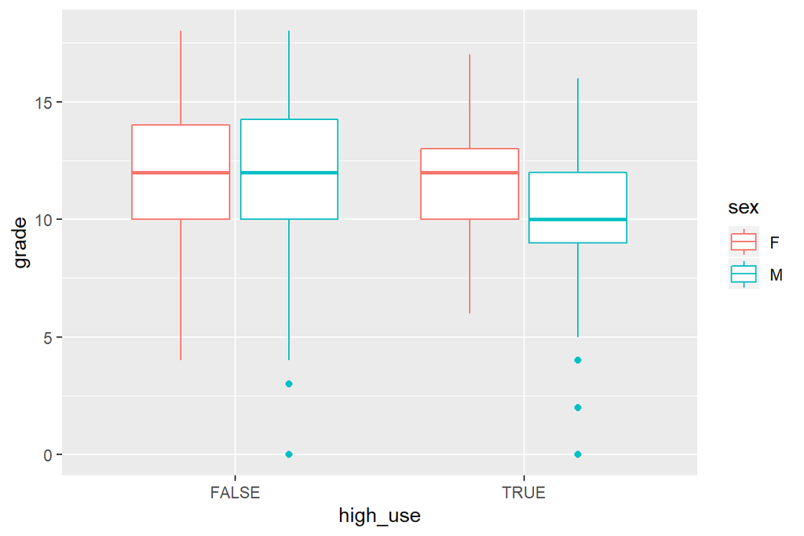

```r
## initialize a plot of high_use and G3
g1 <- ggplot(alc, aes(x = high_use, y = G3, col = sex))

## define the plot as a boxplot and draw it
g1 + geom_boxplot() + ylab("grade")
```

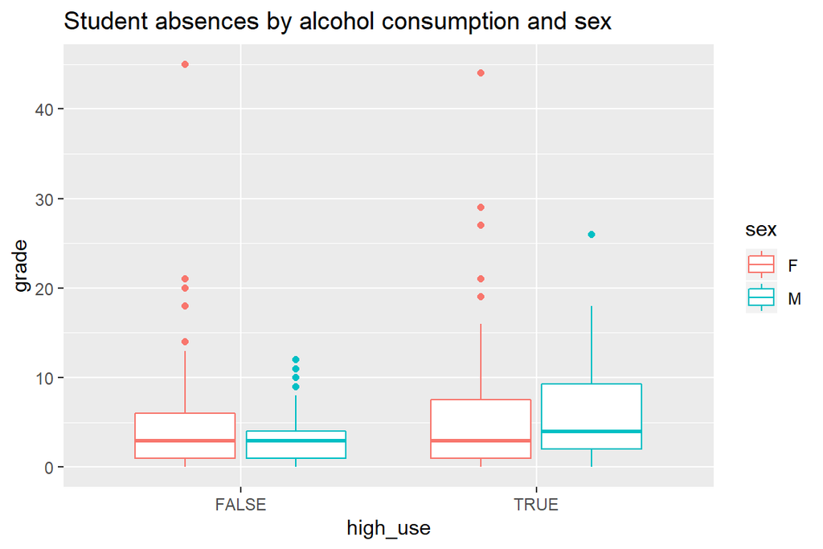

```r
## initialise a plot of high_use and absences

g1 <- ggplot(alc, aes(x = high_use, y = absences, col = sex))
## define the plot as a boxplot and draw it

g1 + geom_boxplot() + ylab("grade")+ ggtitle("Student absences by alcohol consumption and sex")
```

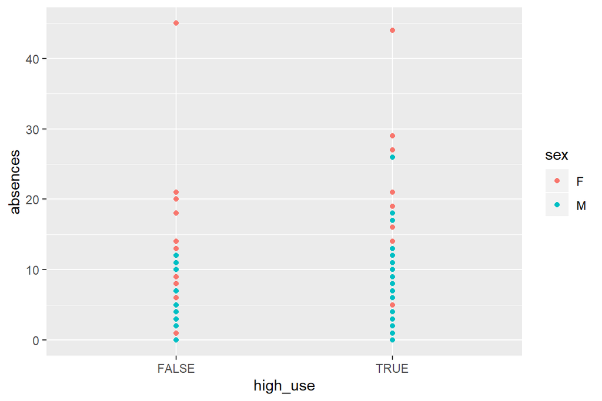

```r
g1+geom_point()
```

```r
##the box plot shows that the males of significantly lower  greades have a higher prevalence in terms of high alocohol usage compared to female.
##Regarding non usage of alocohol, the difference in between the gender is apparently trivial.
```

```r
##question number 5
## find the model with glm()
my_model_1 <- glm(high_use ~ failures + absences + sex+ romantic, data = alc, family = "binomial")

## compute odds ratios (OR)
OR <- coef(my_model_1) %>% exp

## compute confidence intervals (CI)
CI <- confint(my_model_1) %>% exp
## print out the odds ratios with their confidence intervals
cbind(OR, CI)
```

```
##                    OR      2.5 %    97.5 %
## (Intercept) 0.1606994 0.09898897 0.2519302
## failures    1.5740272 1.08568128 2.3050629
## absences    1.0994355 1.05336109 1.1527402
## sexM        2.5301750 1.58131504 4.1005152
## romanticyes 0.7799690 0.46257612 1.2936660
```

```r
##odd ratio and confidence ratio of significant predictors in previous models
##                     OR      2.5 %    97.5 %
##  (Intercept) 0.1606994 0.09898897 0.2519302
##  failures    1.5740272 1.08568128 2.3050629
##  absences    1.0994355 1.05336109 1.1527402
##  sexM        2.5301750 1.58131504 4.1005152
##  romanticyes 0.7799690 0.46257612 1.2936660

##the variable of high failures had 1.56 times higher odds of high alocohol usage(95% CI= 1.08 to 2.3)
##the variable of absences  had 1.09 times higher odds of high alocohol usage(95% CI= 1.05 to 1.15)
##the variable of sex had 2.53 times higher odds of high alocohol usage(95% CI= 1.58 to 4.1)
```

## Summary statistics by group

```r
alc%>% group_by(sex) %>% summarise(count = n(), mean_absences = mean(absences), mean_failures = mean(failures))
```

```
## # A tibble: 2 x 4
##   sex   count mean_absences mean_failures
##   <fct> <int>         <dbl>         <dbl>
## 1 F       198          4.77         0.152
## 2 M       184          4.21         0.255
```

## Performing 10-fold cross-validation on my_model_1

```r
## define a loss function (average prediction error)
loss_func <- function(class, prob) {
  n_wrong <- abs(class - prob) > 0.5
  mean(n_wrong)
}

## compute the average number of wrong predictions in the (training) data

loss_func(class = alc$high_use, prob = alc$probability)
```

```
## [1] NaN
```

```r
## K-fold cross-validation
library(boot)
cv <- cv.glm(data = alc, cost = loss_func, glmfit = my_model_1, K = 10)

## average number of wrong predictions in the cross validation

cv$delta[1]
```

```
## [1] 0.2539267
```

# Chapter 4: Classification and clustering

I will analyze Boston data set available in MASS package.

setwd(“C:/Users/ferozef/Documents/R/IODS-project”)

setwd(“C:/Users/Fariah/Documents/IODS-project”)

###More information on Boston data set:

https://stat.ethz.ch/R-manual/R-devel/library/MASS/html/Boston.html

##Load Boston data set

Boston data set contains 506 housing observation (rows) with 14 variables (columns).

```r
library(MASS)
data('Boston')
str(Boston)
```

```
## 'data.frame':    506 obs. of  14 variables:
##  $ crim   : num  0.00632 0.02731 0.02729 0.03237 0.06905 ...
##  $ zn     : num  18 0 0 0 0 0 12.5 12.5 12.5 12.5 ...
##  $ indus  : num  2.31 7.07 7.07 2.18 2.18 2.18 7.87 7.87 7.87 7.87 ...
##  $ chas   : int  0 0 0 0 0 0 0 0 0 0 ...
##  $ nox    : num  0.538 0.469 0.469 0.458 0.458 0.458 0.524 0.524 0.524 0.524 ...
##  $ rm     : num  6.58 6.42 7.18 7 7.15 ...
##  $ age    : num  65.2 78.9 61.1 45.8 54.2 58.7 66.6 96.1 100 85.9 ...
##  $ dis    : num  4.09 4.97 4.97 6.06 6.06 ...
##  $ rad    : int  1 2 2 3 3 3 5 5 5 5 ...
##  $ tax    : num  296 242 242 222 222 222 311 311 311 311 ...
##  $ ptratio: num  15.3 17.8 17.8 18.7 18.7 18.7 15.2 15.2 15.2 15.2 ...
##  $ black  : num  397 397 393 395 397 ...
##  $ lstat  : num  4.98 9.14 4.03 2.94 5.33 ...
##  $ medv   : num  24 21.6 34.7 33.4 36.2 28.7 22.9 27.1 16.5 18.9 ...
```

```r
summary(Boston)
```

```
##       crim                zn             indus            chas
##  Min.   : 0.00632   Min.   :  0.00   Min.   : 0.46   Min.   :0.00000
##  1st Qu.: 0.08204   1st Qu.:  0.00   1st Qu.: 5.19   1st Qu.:0.00000
##  Median : 0.25651   Median :  0.00   Median : 9.69   Median :0.00000
##  Mean   : 3.61352   Mean   : 11.36   Mean   :11.14   Mean   :0.06917
##  3rd Qu.: 3.67708   3rd Qu.: 12.50   3rd Qu.:18.10   3rd Qu.:0.00000
##  Max.   :88.97620   Max.   :100.00   Max.   :27.74   Max.   :1.00000
##       nox               rm             age              dis
##  Min.   :0.3850   Min.   :3.561   Min.   :  2.90   Min.   : 1.130
##  1st Qu.:0.4490   1st Qu.:5.886   1st Qu.: 45.02   1st Qu.: 2.100
##  Median :0.5380   Median :6.208   Median : 77.50   Median : 3.207
##  Mean   :0.5547   Mean   :6.285   Mean   : 68.57   Mean   : 3.795
##  3rd Qu.:0.6240   3rd Qu.:6.623   3rd Qu.: 94.08   3rd Qu.: 5.188
##  Max.   :0.8710   Max.   :8.780   Max.   :100.00   Max.   :12.127
##       rad              tax           ptratio          black
##  Min.   : 1.000   Min.   :187.0   Min.   :12.60   Min.   :  0.32
##  1st Qu.: 4.000   1st Qu.:279.0   1st Qu.:17.40   1st Qu.:375.38
##  Median : 5.000   Median :330.0   Median :19.05   Median :391.44
##  Mean   : 9.549   Mean   :408.2   Mean   :18.46   Mean   :356.67
##  3rd Qu.:24.000   3rd Qu.:666.0   3rd Qu.:20.20   3rd Qu.:396.23
##  Max.   :24.000   Max.   :711.0   Max.   :22.00   Max.   :396.90
##      lstat            medv
##  Min.   : 1.73   Min.   : 5.00
##  1st Qu.: 6.95   1st Qu.:17.02
##  Median :11.36   Median :21.20
##  Mean   :12.65   Mean   :22.53
##  3rd Qu.:16.95   3rd Qu.:25.00
##  Max.   :37.97   Max.   :50.00
```

## Visualize and summarize data

Nice corrplot modification examples https://cran.r-project.org/web/packages/corrplot/vignettes/corrplot-intro.html

```r
library(corrplot)
correlation <- cor(Boston)
round(correlation, digits = 2)
```

```
##          crim    zn indus  chas   nox    rm   age   dis   rad   tax
## crim     1.00 -0.20  0.41 -0.06  0.42 -0.22  0.35 -0.38  0.63  0.58
## zn      -0.20  1.00 -0.53 -0.04 -0.52  0.31 -0.57  0.66 -0.31 -0.31
## indus    0.41 -0.53  1.00  0.06  0.76 -0.39  0.64 -0.71  0.60  0.72
## chas    -0.06 -0.04  0.06  1.00  0.09  0.09  0.09 -0.10 -0.01 -0.04
## nox      0.42 -0.52  0.76  0.09  1.00 -0.30  0.73 -0.77  0.61  0.67
## rm      -0.22  0.31 -0.39  0.09 -0.30  1.00 -0.24  0.21 -0.21 -0.29
## age      0.35 -0.57  0.64  0.09  0.73 -0.24  1.00 -0.75  0.46  0.51
## dis     -0.38  0.66 -0.71 -0.10 -0.77  0.21 -0.75  1.00 -0.49 -0.53
## rad      0.63 -0.31  0.60 -0.01  0.61 -0.21  0.46 -0.49  1.00  0.91
## tax      0.58 -0.31  0.72 -0.04  0.67 -0.29  0.51 -0.53  0.91  1.00
## ptratio  0.29 -0.39  0.38 -0.12  0.19 -0.36  0.26 -0.23  0.46  0.46
## black   -0.39  0.18 -0.36  0.05 -0.38  0.13 -0.27  0.29 -0.44 -0.44
## lstat    0.46 -0.41  0.60 -0.05  0.59 -0.61  0.60 -0.50  0.49  0.54
## medv    -0.39  0.36 -0.48  0.18 -0.43  0.70 -0.38  0.25 -0.38 -0.47
##         ptratio black lstat  medv
## crim       0.29 -0.39  0.46 -0.39
## zn        -0.39  0.18 -0.41  0.36
## indus      0.38 -0.36  0.60 -0.48
## chas      -0.12  0.05 -0.05  0.18
## nox        0.19 -0.38  0.59 -0.43
## rm        -0.36  0.13 -0.61  0.70
## age        0.26 -0.27  0.60 -0.38
## dis       -0.23  0.29 -0.50  0.25
## rad        0.46 -0.44  0.49 -0.38
## tax        0.46 -0.44  0.54 -0.47
## ptratio    1.00 -0.18  0.37 -0.51
## black     -0.18  1.00 -0.37  0.33
## lstat      0.37 -0.37  1.00 -0.74
## medv      -0.51  0.33 -0.74  1.00
```

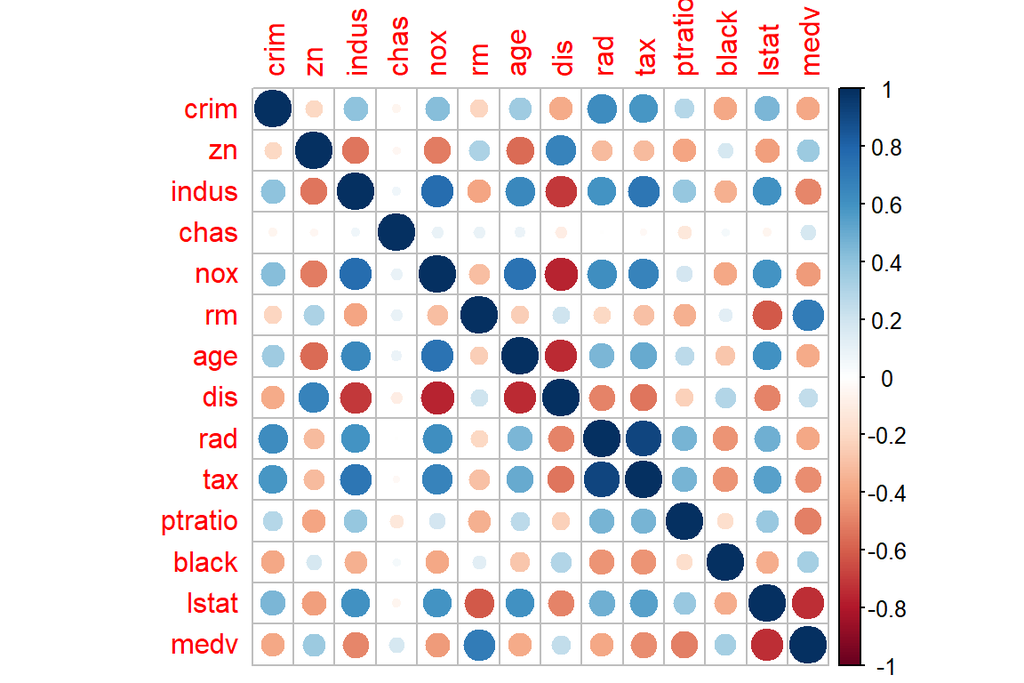

```r
corrplot(correlation, method="circle")
```

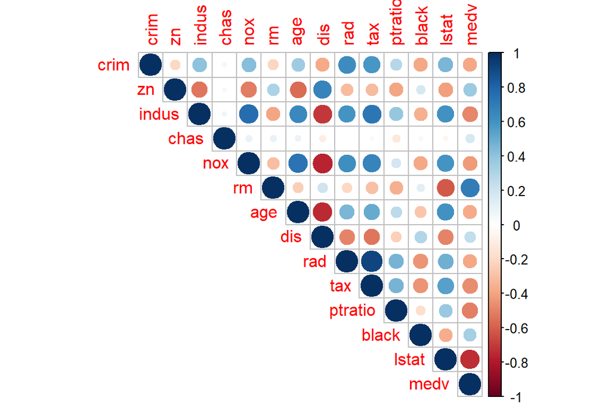

```r
corrplot(correlation, type = 'upper')
```

negative correlation in red and positive correlation in blue. Narrowness of `method = 'circle'` Darkness/weakness of colour indicates how high/low correlation are respectively.

From the graph it can be observed that most of the variables correlate significantly with other variables. Only few pairs are not significantly correlated.

## Scaling and categorising the variables

To classify our data, variable values need to be standarized/scaled so that all variables have a mean value to zero `0´. It is done as follows (when all variables are numerical, as expected for classification analysis):

```r
scaled <- as.data.frame(scale(Boston))
class(scaled)
```

```
## [1] "data.frame"
```

```r
str(scaled)
```

```
## 'data.frame':    506 obs. of  14 variables:
##  $ crim   : num  -0.419 -0.417 -0.417 -0.416 -0.412 ...
##  $ zn     : num  0.285 -0.487 -0.487 -0.487 -0.487 ...
##  $ indus  : num  -1.287 -0.593 -0.593 -1.306 -1.306 ...
##  $ chas   : num  -0.272 -0.272 -0.272 -0.272 -0.272 ...
##  $ nox    : num  -0.144 -0.74 -0.74 -0.834 -0.834 ...
##  $ rm     : num  0.413 0.194 1.281 1.015 1.227 ...
##  $ age    : num  -0.12 0.367 -0.266 -0.809 -0.511 ...
##  $ dis    : num  0.14 0.557 0.557 1.077 1.077 ...
##  $ rad    : num  -0.982 -0.867 -0.867 -0.752 -0.752 ...
##  $ tax    : num  -0.666 -0.986 -0.986 -1.105 -1.105 ...
##  $ ptratio: num  -1.458 -0.303 -0.303 0.113 0.113 ...
##  $ black  : num  0.441 0.441 0.396 0.416 0.441 ...
##  $ lstat  : num  -1.074 -0.492 -1.208 -1.36 -1.025 ...
##  $ medv   : num  0.16 -0.101 1.323 1.182 1.486 ...
```

```r
summary(scaled)
```

```
##       crim                 zn               indus
##  Min.   :-0.419367   Min.   :-0.48724   Min.   :-1.5563
##  1st Qu.:-0.410563   1st Qu.:-0.48724   1st Qu.:-0.8668
##  Median :-0.390280   Median :-0.48724   Median :-0.2109
##  Mean   : 0.000000   Mean   : 0.00000   Mean   : 0.0000
##  3rd Qu.: 0.007389   3rd Qu.: 0.04872   3rd Qu.: 1.0150
##  Max.   : 9.924110   Max.   : 3.80047   Max.   : 2.4202
##       chas              nox                rm               age
##  Min.   :-0.2723   Min.   :-1.4644   Min.   :-3.8764   Min.   :-2.3331
##  1st Qu.:-0.2723   1st Qu.:-0.9121   1st Qu.:-0.5681   1st Qu.:-0.8366
##  Median :-0.2723   Median :-0.1441   Median :-0.1084   Median : 0.3171
##  Mean   : 0.0000   Mean   : 0.0000   Mean   : 0.0000   Mean   : 0.0000
##  3rd Qu.:-0.2723   3rd Qu.: 0.5981   3rd Qu.: 0.4823   3rd Qu.: 0.9059
##  Max.   : 3.6648   Max.   : 2.7296   Max.   : 3.5515   Max.   : 1.1164
##       dis               rad               tax             ptratio
##  Min.   :-1.2658   Min.   :-0.9819   Min.   :-1.3127   Min.   :-2.7047
##  1st Qu.:-0.8049   1st Qu.:-0.6373   1st Qu.:-0.7668   1st Qu.:-0.4876
##  Median :-0.2790   Median :-0.5225   Median :-0.4642   Median : 0.2746
##  Mean   : 0.0000   Mean   : 0.0000   Mean   : 0.0000   Mean   : 0.0000
##  3rd Qu.: 0.6617   3rd Qu.: 1.6596   3rd Qu.: 1.5294   3rd Qu.: 0.8058
##  Max.   : 3.9566   Max.   : 1.6596   Max.   : 1.7964   Max.   : 1.6372
##      black             lstat              medv
##  Min.   :-3.9033   Min.   :-1.5296   Min.   :-1.9063
##  1st Qu.: 0.2049   1st Qu.:-0.7986   1st Qu.:-0.5989
##  Median : 0.3808   Median :-0.1811   Median :-0.1449
##  Mean   : 0.0000   Mean   : 0.0000   Mean   : 0.0000
##  3rd Qu.: 0.4332   3rd Qu.: 0.6024   3rd Qu.: 0.2683
##  Max.   : 0.4406   Max.   : 3.5453   Max.   : 2.9865
```

`crim` is categorised according to quantiles and later will be used to train the model to predict the right crime rate class of an observation based on other variables.

```r
bins = quantile(scaled$crim)
crime <- cut(scaled$crim, breaks = bins, label = c('low', 'med_low', 'med_high', 'high'), include.lowest = TRUE)
#count table for each category level
table(crime)
```

```
## crime
##      low  med_low med_high     high
##      127      126      126      127
```

```r
#replace original crim with categorical crime variable
scaled <- dplyr::select(scaled, -crim)
scaled <- data.frame(scaled, crime)
head(scaled)
```

```
##           zn      indus       chas        nox        rm        age
## 1  0.2845483 -1.2866362 -0.2723291 -0.1440749 0.4132629 -0.1198948
## 2 -0.4872402 -0.5927944 -0.2723291 -0.7395304 0.1940824  0.3668034
## 3 -0.4872402 -0.5927944 -0.2723291 -0.7395304 1.2814456 -0.2655490
## 4 -0.4872402 -1.3055857 -0.2723291 -0.8344581 1.0152978 -0.8090878
## 5 -0.4872402 -1.3055857 -0.2723291 -0.8344581 1.2273620 -0.5106743
## 6 -0.4872402 -1.3055857 -0.2723291 -0.8344581 0.2068916 -0.3508100
##        dis        rad        tax    ptratio     black      lstat
## 1 0.140075 -0.9818712 -0.6659492 -1.4575580 0.4406159 -1.0744990
## 2 0.556609 -0.8670245 -0.9863534 -0.3027945 0.4406159 -0.4919525
## 3 0.556609 -0.8670245 -0.9863534 -0.3027945 0.3960351 -1.2075324
## 4 1.076671 -0.7521778 -1.1050216  0.1129203 0.4157514 -1.3601708
## 5 1.076671 -0.7521778 -1.1050216  0.1129203 0.4406159 -1.0254866
## 6 1.076671 -0.7521778 -1.1050216  0.1129203 0.4101651 -1.0422909
##         medv crime
## 1  0.1595278   low
## 2 -0.1014239   low
## 3  1.3229375   low
## 4  1.1815886   low
## 5  1.4860323   low
## 6  0.6705582   low
```

## Divide data for training and test sets

To demonstrate, how well my model is predicting crime rate, I will use the cut-off values (20%) proportion of the variable data for testing it, so that 80% of the data belongs to the train set. Observations are selected randomly below for training or test sets.

```r
random_test_rows <- sample(nrow(scaled), size = nrow(scaled) * 0.2)
test_set <- scaled[random_test_rows, ]
train_set <- scaled[-random_test_rows, ]
#Check that resulting dfs are as should
dim(test_set)
```

```
## [1] 101  14
```

```r
dim(train_set)
```

```
## [1] 405  14
```

## Fitting linear discriminant analysis for crimes

I used lda() function for Fitting classification model using crimes as a categorical variable and all other (continuous) variables as predicting variables.

```r
lda_fit <- lda(crime ~ ., data = train_set)
lda_fit
```

```
## Call:
## lda(crime ~ ., data = train_set)
##
## Prior probabilities of groups:
##       low   med_low  med_high      high
## 0.2617284 0.2518519 0.2370370 0.2493827
##
## Group means:
##                   zn       indus        chas        nox          rm
## low       0.94226736 -0.95167904 -0.08661679 -0.8742853  0.41780121
## med_low  -0.09714232 -0.26998186 -0.04073494 -0.5710887 -0.10512109
## med_high -0.37915407  0.09348591  0.21980846  0.3659817  0.08625636
## high     -0.48724019  1.01499462 -0.11640431  1.0309437 -0.39164849
##                 age        dis        rad        tax    ptratio      black
## low      -0.8746423  0.8987210 -0.6925875 -0.7224285 -0.4465952  0.3780424
## med_low  -0.3361470  0.3424649 -0.5528850 -0.4786977 -0.1130510  0.3170291
## med_high  0.4002935 -0.3701354 -0.4519015 -0.3571028 -0.2517924  0.1029577
## high      0.8106953 -0.8535133  1.6596029  1.5294129  0.8057784 -0.7820224
##                lstat        medv
## low      -0.77232678  0.48694833
## med_low  -0.13166391  0.02318905
## med_high  0.04503872  0.13064641
## high      0.91233713 -0.71558624
##
## Coefficients of linear discriminants:
##                 LD1         LD2         LD3
## zn       0.13403797  0.67636890 -0.93754830
## indus    0.11496307 -0.23068393  0.64449887
## chas    -0.09594329 -0.02876405  0.02436756
## nox      0.15590135 -0.72972729 -1.62090162
## rm      -0.12652056 -0.10182192 -0.09629065
## age      0.27364892 -0.23933721 -0.14219296
## dis     -0.06939526 -0.10506430  0.10053593
## rad      4.07450043  0.91969775  0.14075154
## tax      0.03653670  0.02894681  0.35464369
## ptratio  0.13381276  0.07606692 -0.46235518
## black   -0.13125120  0.01767948  0.15755456
## lstat    0.16077734 -0.32243634  0.31905058
## medv     0.16642082 -0.35962863 -0.22822240
##
## Proportion of trace:
##    LD1    LD2    LD3
## 0.9639 0.0265 0.0096
```

LD1 has the highest proportions of variable as its predictors, as evident from the results.

## Visualization of model

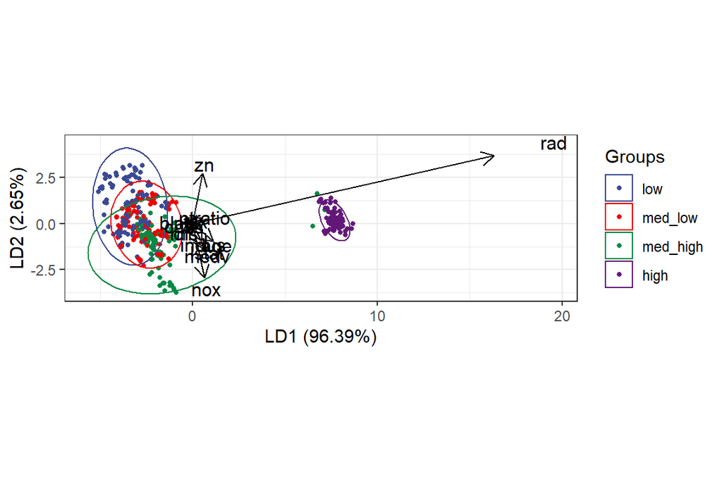

```r
#Convert crime factor levels to numeric to plot in different colors
crime_levels <- as.numeric(train_set$crime)
#I hate the default colors of the plot, so I'm using ggsci package palettes instead
#Good source for color palettes https://www.datanovia.com/en/blog/top-r-color-palettes-to-know-for-great-data-visualization/
library(ggsci)
library(devtools)
install_github("fawda123/ggord")
library(ggord)
cols <- pal_aaas()(4)
#Plot with nicer colors
ggord(lda_fit, train_set$crime, poly = FALSE, arrow=.3, veclsz = .5, vec_ext = 4, size=1, cols = cols)
```

## Test model

I created corrected crime classes for the test data and removed crime variable from test data that is used to predict the classes with the `lda_fit`.

```r
#Save correct classes to variable
correct_classes <- test_set$crime
#Remove classes from test data
test_set <- dplyr::select(test_set, -crime)
#Predict classes with model
lda_predict <- predict(lda_fit, newdata = test_set)
#Make 2X2 table to observe model accuracy
table(correct = correct_classes, predicted = lda_predict$class)
```

```
##           predicted
## correct    low med_low med_high high
##   low       13       7        1    0
##   med_low    3      17        4    0
##   med_high   0       6       21    3
##   high       0       0        1   25
```

```r
#Calculate percentage of right predictions on test data
percent_correct <- 100 * mean(lda_predict$class==correct_classes)
percent_correct <- round(percent_correct, digits = 0)
percent_correct
```

```
## [1] 75
```

The table shows the actual and predicted categories. The model predicts best the category of highs - aligned with the graphical observation above. With other categories there are errors, but majority is correct.

## K-means and distances

```r
# re-data loading again and standardize it
data(Boston)
boston_sc <- scale(Boston)
# Compute distances (Euclidean is the default)
dist_eu <- dist(boston_sc)
dist_man <- dist(boston_sc, method="manhattan")
summary(dist_eu)
```

```
##    Min. 1st Qu.  Median    Mean 3rd Qu.    Max.
##  0.1343  3.4625  4.8241  4.9111  6.1863 14.3970
```

```r
summary(dist_man)
```

```
##    Min. 1st Qu.  Median    Mean 3rd Qu.    Max.
##  0.2662  8.4832 12.6090 13.5488 17.7568 48.8618
```

## K-means clustering

```r
km <- kmeans(boston_sc, centers = 4)
```

Well that was simple. Let’s see what is the best number of clusters with a qplot. library(ggplot2)

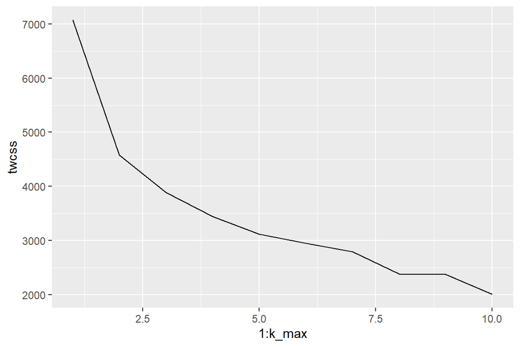

```r
# K-means might produce different results every time, because it randomly assigns the initial cluster centers. The function set.seed() can be used to deal with that.
set.seed(123)
# set the max number of clusters
k_max <- 10
# count the WCSS = within cluster sum of squares and plot it
twcss <- sapply(1:k_max, function(k){kmeans(boston_sc, k)$tot.withinss})
qplot(x = 1:k_max, y = twcss, geom = 'line')
```

To find the optimal number off clusters I used WCSS method. It tells how close the observations are to the cluster center. From the above graph the optimum number of clusters should be 2 (there is sudden drop from 2, see x-axis).

## Visualize the clusters

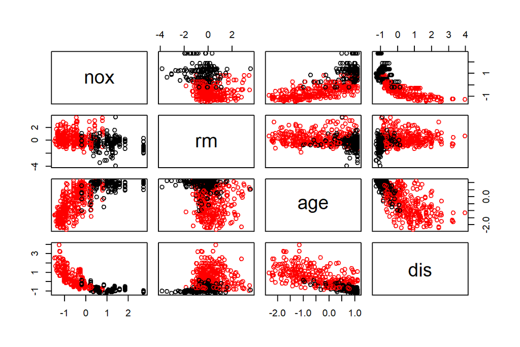

```r
boston_sc <- as.data.frame(boston_sc)
# run kmeans again with 2 centroids
km <- kmeans(boston_sc, centers = 2)
# visualize the clusters
pairs(boston_sc[5:8], col = km$cluster)
```

# Chapter 5: Dimensionality reduction techniques

## loading and cleaning the data

```r
library(stringr)
library(dplyr)

human <- read.csv("http://s3.amazonaws.com/assets.datacamp.com/production/course_2218/datasets/human1.txt", stringsAsFactors = F)

str(human$GNI)
```

```
##  chr [1:195] "64,992" "42,261" "56,431" "44,025" "45,435" "43,919" ...
```

```r
human <- mutate(human, GNI = str_replace(human$GNI, pattern=",", replace ="") %>% as.numeric)
str(human$GNI)
```

```
##  num [1:195] 64992 42261 56431 44025 45435 ...
```

#Excluding the unwanted variables

```r
names(human)
```

```
##  [1] "HDI.Rank"       "Country"        "HDI"            "Life.Exp"
##  [5] "Edu.Exp"        "Edu.Mean"       "GNI"            "GNI.Minus.Rank"
##  [9] "GII.Rank"       "GII"            "Mat.Mor"        "Ado.Birth"
## [13] "Parli.F"        "Edu2.F"         "Edu2.M"         "Labo.F"
## [17] "Labo.M"         "Edu2.FM"        "Labo.FM"
```

```r
keep <- c("Country", "Edu2.FM", "Labo.FM", "Life.Exp", "Edu.Exp", "GNI", "Mat.Mor", "Ado.Birth", "Parli.F")
human <- dplyr::select(human, one_of(keep))
```

#Keeping only the vaules which are ‘TRUE’ and removing all rows with missing values i.e ‘FALSE’

```r
complete.cases(human)
```

```
##   [1]  TRUE  TRUE  TRUE  TRUE  TRUE  TRUE  TRUE  TRUE  TRUE  TRUE  TRUE
##  [12] FALSE FALSE  TRUE  TRUE  TRUE  TRUE  TRUE  TRUE  TRUE  TRUE  TRUE
##  [23]  TRUE  TRUE  TRUE  TRUE  TRUE  TRUE  TRUE  TRUE FALSE  TRUE  TRUE
##  [34] FALSE  TRUE  TRUE  TRUE  TRUE  TRUE  TRUE  TRUE  TRUE  TRUE  TRUE
##  [45]  TRUE  TRUE  TRUE  TRUE  TRUE  TRUE  TRUE  TRUE  TRUE  TRUE  TRUE
##  [56]  TRUE  TRUE FALSE  TRUE FALSE  TRUE  TRUE  TRUE FALSE  TRUE  TRUE
##  [67]  TRUE  TRUE  TRUE  TRUE  TRUE  TRUE  TRUE  TRUE  TRUE  TRUE FALSE
##  [78]  TRUE FALSE  TRUE  TRUE  TRUE  TRUE  TRUE  TRUE  TRUE  TRUE  TRUE
##  [89] FALSE  TRUE  TRUE  TRUE  TRUE FALSE  TRUE  TRUE  TRUE FALSE  TRUE
## [100]  TRUE  TRUE  TRUE  TRUE  TRUE  TRUE  TRUE  TRUE  TRUE FALSE  TRUE
## [111]  TRUE  TRUE FALSE FALSE  TRUE  TRUE  TRUE  TRUE  TRUE  TRUE  TRUE
## [122] FALSE FALSE  TRUE  TRUE  TRUE  TRUE  TRUE  TRUE  TRUE  TRUE  TRUE
## [133] FALSE  TRUE FALSE  TRUE FALSE FALSE  TRUE  TRUE FALSE  TRUE  TRUE
## [144] FALSE  TRUE  TRUE  TRUE  TRUE FALSE  TRUE  TRUE FALSE  TRUE FALSE
## [155]  TRUE  TRUE FALSE  TRUE FALSE  TRUE  TRUE  TRUE  TRUE  TRUE  TRUE
## [166]  TRUE  TRUE FALSE FALSE  TRUE  TRUE  TRUE  TRUE  TRUE  TRUE  TRUE
## [177]  TRUE FALSE  TRUE  TRUE  TRUE FALSE  TRUE  TRUE  TRUE FALSE  TRUE
## [188]  TRUE  TRUE  TRUE  TRUE  TRUE  TRUE  TRUE  TRUE
```

```r
data.frame(human [-1], comp=complete.cases(human))
```

```
##       Edu2.FM   Labo.FM Life.Exp Edu.Exp    GNI Mat.Mor Ado.Birth Parli.F
## 1   1.0072389 0.8908297     81.6    17.5  64992       4       7.8    39.6
## 2   0.9968288 0.8189415     82.4    20.2  42261       6      12.1    30.5
## 3   0.9834369 0.8251001     83.0    15.8  56431       6       1.9    28.5
## 4   0.9886128 0.8840361     80.2    18.7  44025       5       5.1    38.0
## 5   0.9690608 0.8286119     81.6    17.9  45435       6       6.2    36.9
## 6   0.9927835 0.8072289     80.9    16.5  43919       7       3.8    36.9
## 7   1.0241730 0.7797357     80.9    18.6  39568       9       8.2    19.9
## 8   1.0031646 0.8171263     79.1    16.5  52947      28      31.0    19.4
## 9   1.0000000 0.8676056     82.0    15.9  42155      11      14.5    28.2
## 10  0.9968520 0.8401084     81.8    19.2  32689       8      25.3    31.4
## 11  0.9148148 0.7616580     83.0    15.4  76628       6       6.0    25.3
## 12  0.9116162 0.7566372     84.0    15.6  53959      NA       3.3      NA
## 13         NA        NA     80.0    15.0  79851      NA        NA    20.0
## 14  0.9908362 0.8880707     82.2    15.8  45636       4       6.5    43.6
```

[output cut: 377 more lines]

```r
human_ <- filter(human, complete.cases(human))
complete.cases(human_)
```

```
##   [1] TRUE TRUE TRUE TRUE TRUE TRUE TRUE TRUE TRUE TRUE TRUE TRUE TRUE TRUE
##  [15] TRUE TRUE TRUE TRUE TRUE TRUE TRUE TRUE TRUE TRUE TRUE TRUE TRUE TRUE
##  [29] TRUE TRUE TRUE TRUE TRUE TRUE TRUE TRUE TRUE TRUE TRUE TRUE TRUE TRUE
##  [43] TRUE TRUE TRUE TRUE TRUE TRUE TRUE TRUE TRUE TRUE TRUE TRUE TRUE TRUE
##  [57] TRUE TRUE TRUE TRUE TRUE TRUE TRUE TRUE TRUE TRUE TRUE TRUE TRUE TRUE
##  [71] TRUE TRUE TRUE TRUE TRUE TRUE TRUE TRUE TRUE TRUE TRUE TRUE TRUE TRUE
##  [85] TRUE TRUE TRUE TRUE TRUE TRUE TRUE TRUE TRUE TRUE TRUE TRUE TRUE TRUE
##  [99] TRUE TRUE TRUE TRUE TRUE TRUE TRUE TRUE TRUE TRUE TRUE TRUE TRUE TRUE
## [113] TRUE TRUE TRUE TRUE TRUE TRUE TRUE TRUE TRUE TRUE TRUE TRUE TRUE TRUE
## [127] TRUE TRUE TRUE TRUE TRUE TRUE TRUE TRUE TRUE TRUE TRUE TRUE TRUE TRUE
## [141] TRUE TRUE TRUE TRUE TRUE TRUE TRUE TRUE TRUE TRUE TRUE TRUE TRUE TRUE
## [155] TRUE TRUE TRUE TRUE TRUE TRUE TRUE TRUE
```

#Removing the data relate to regions instead of countries

```r
dim(human_)
```

```
## [1] 162   9
```

```r
tail(human_, n=10)
```

```
##                             Country   Edu2.FM   Labo.FM Life.Exp Edu.Exp
## 153                            Chad 0.1717172 0.8080808     51.6     7.4
## 154        Central African Republic 0.3782772 0.8531140     50.7     7.2
## 155                           Niger 0.3076923 0.4459309     61.4     5.4
## 156                     Arab States 0.7289916 0.3081009     70.6    12.0
## 157       East Asia and the Pacific 0.8250377 0.7884131     74.0    12.7
## 158         Europe and Central Asia 0.8784119 0.6514286     72.3    13.6
## 159 Latin America and the Caribbean 0.9836957 0.6729323     75.0    14.0
## 160                      South Asia 0.5329670 0.3711083     68.4    11.2
## 161              Sub-Saharan Africa 0.7015873 0.8537859     58.5     9.6
## 162                           World 0.8333333 0.6558018     71.5    12.2
##       GNI Mat.Mor Ado.Birth Parli.F
## 153  2085     980     152.0    14.9
## 154   581     880      98.3    12.5
## 155   908     630     204.8    13.3
## 156 15722     155      45.4    14.0
## 157 11449      72      21.2    18.7
## 158 12791      28      30.8    19.0
## 159 14242      85      68.3    27.0
## 160  5605     183      38.7    17.5
## 161  3363     506     109.7    22.5
## 162 14301     210      47.4    21.8
```

```r
last <- nrow(human_) - 7
human_ <- human_[1:last,]
dim(human_)
```

```
## [1] 155   9
```

#Define the row names of the data and remove the country name column from the data.

```r
rownames(human_) <- human_$Country
human_ <- dplyr::select(human_, -Country)
dim(human_)
```

```
## [1] 155   8
```

```r
str(human_)
```

```
## 'data.frame':    155 obs. of  8 variables:
##  $ Edu2.FM  : num  1.007 0.997 0.983 0.989 0.969 ...
##  $ Labo.FM  : num  0.891 0.819 0.825 0.884 0.829 ...
##  $ Life.Exp : num  81.6 82.4 83 80.2 81.6 80.9 80.9 79.1 82 81.8 ...
##  $ Edu.Exp  : num  17.5 20.2 15.8 18.7 17.9 16.5 18.6 16.5 15.9 19.2 ...
##  $ GNI      : num  64992 42261 56431 44025 45435 ...
##  $ Mat.Mor  : int  4 6 6 5 6 7 9 28 11 8 ...
##  $ Ado.Birth: num  7.8 12.1 1.9 5.1 6.2 3.8 8.2 31 14.5 25.3 ...
##  $ Parli.F  : num  39.6 30.5 28.5 38 36.9 36.9 19.9 19.4 28.2 31.4 ...
```

## Graphical overview and summaries of the variables

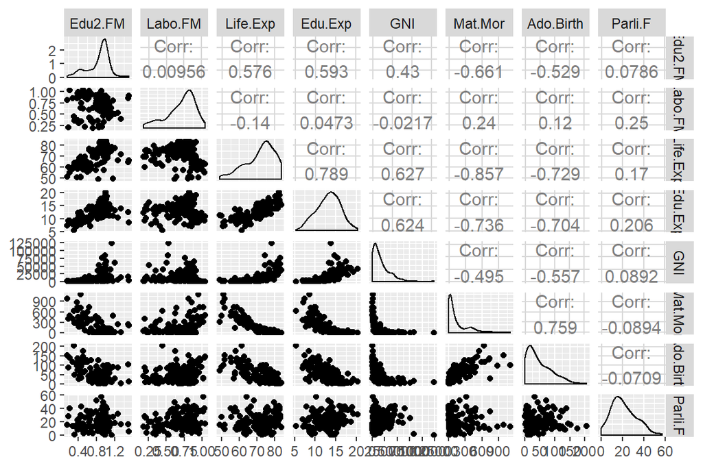

```r
library(GGally); library(ggplot2); library(corrplot)
ggpairs(human_)
```

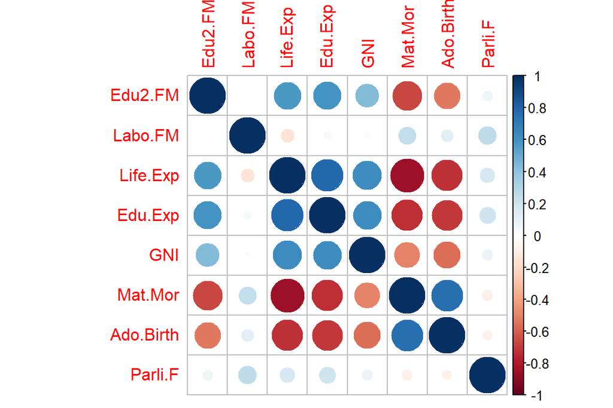

```r
cor(human_)%>%corrplot()
```

## Analysis of PCA without standardized data

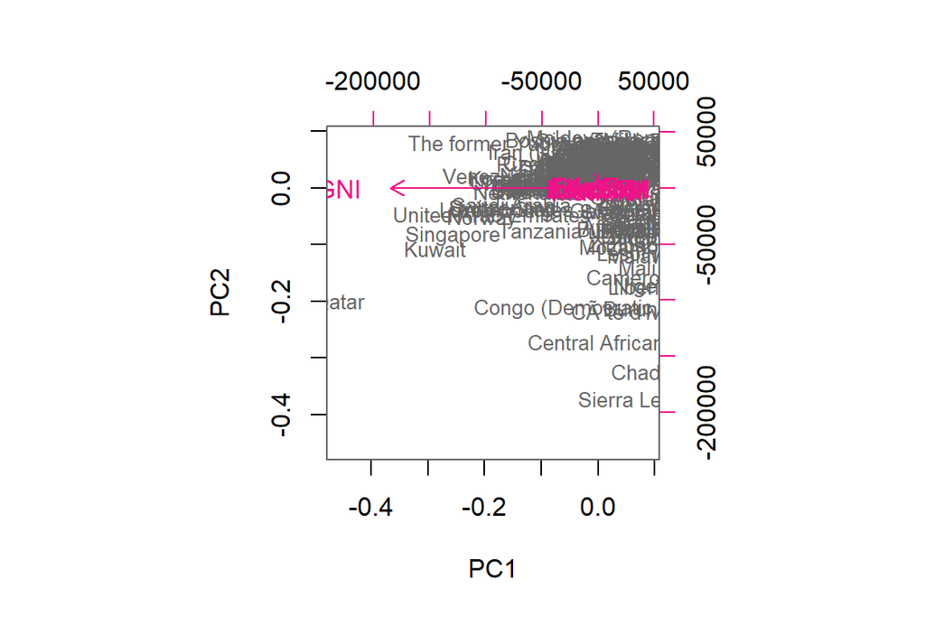

```r
pca_human <- prcomp(human_)
biplot(pca_human, choices = 1:2, cex = c(0.8,1), col = c("grey40", "deeppink2"))
```

## Standardize the variables in the human data and same analysis as above

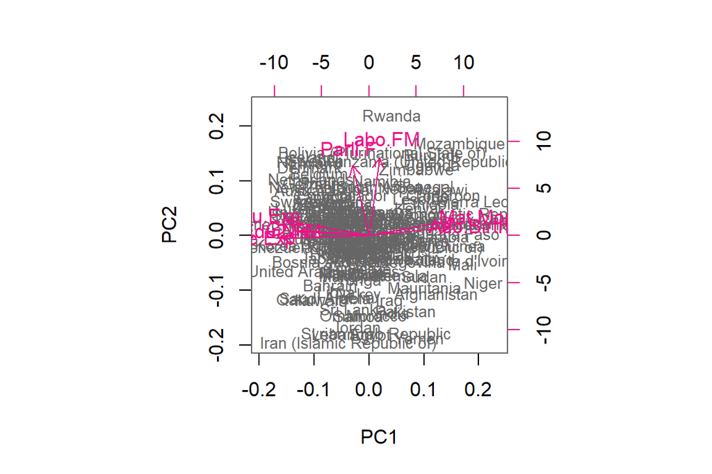

```r
human_std <- scale(human_)
pca_human2 <- prcomp(human_std)
biplot(pca_human2, choices = 1:2, cex = c(0.8,1), col = c("grey40", "deeppink2"))
```

## Exploring the tea data and analyzing

```r
library(ggplot2); library(FactoMineR); library(dplyr); library(tidyr)
data(tea)
str(tea)
```

```
## 'data.frame':    300 obs. of  36 variables:
##  $ breakfast       : Factor w/ 2 levels "breakfast","Not.breakfast": 1 1 2 2 1 2 1 2 1 1 ...
##  $ tea.time        : Factor w/ 2 levels "Not.tea time",..: 1 1 2 1 1 1 2 2 2 1 ...
##  $ evening         : Factor w/ 2 levels "evening","Not.evening": 2 2 1 2 1 2 2 1 2 1 ...
##  $ lunch           : Factor w/ 2 levels "lunch","Not.lunch": 2 2 2 2 2 2 2 2 2 2 ...
##  $ dinner          : Factor w/ 2 levels "dinner","Not.dinner": 2 2 1 1 2 1 2 2 2 2 ...
##  $ always          : Factor w/ 2 levels "always","Not.always": 2 2 2 2 1 2 2 2 2 2 ...
##  $ home            : Factor w/ 2 levels "home","Not.home": 1 1 1 1 1 1 1 1 1 1 ...
##  $ work            : Factor w/ 2 levels "Not.work","work": 1 1 2 1 1 1 1 1 1 1 ...
##  $ tearoom         : Factor w/ 2 levels "Not.tearoom",..: 1 1 1 1 1 1 1 1 1 2 ...
##  $ friends         : Factor w/ 2 levels "friends","Not.friends": 2 2 1 2 2 2 1 2 2 2 ...
##  $ resto           : Factor w/ 2 levels "Not.resto","resto": 1 1 2 1 1 1 1 1 1 1 ...
##  $ pub             : Factor w/ 2 levels "Not.pub","pub": 1 1 1 1 1 1 1 1 1 1 ...
##  $ Tea             : Factor w/ 3 levels "black","Earl Grey",..: 1 1 2 2 2 2 2 1 2 1 ...
##  $ How             : Factor w/ 4 levels "alone","lemon",..: 1 3 1 1 1 1 1 3 3 1 ...
```

[output cut: 22 more lines]

```r
dim(tea)
```

```
## [1] 300  36
```

```r
keep_columns <- c("Tea", "How", "how", "sugar", "where", "lunch")
tea_time <- dplyr::select(tea, one_of(keep_columns))
summary(tea_time)
```

```
##         Tea         How                      how           sugar
##  black    : 74   alone:195   tea bag           :170   No.sugar:155
##  Earl Grey:193   lemon: 33   tea bag+unpackaged: 94   sugar   :145
##  green    : 33   milk : 63   unpackaged        : 36
##                  other:  9
##                   where           lunch
##  chain store         :192   lunch    : 44
##  chain store+tea shop: 78   Not.lunch:256
##  tea shop            : 30
##
```

```r
str(tea_time)
```

```
## 'data.frame':    300 obs. of  6 variables:
##  $ Tea  : Factor w/ 3 levels "black","Earl Grey",..: 1 1 2 2 2 2 2 1 2 1 ...
##  $ How  : Factor w/ 4 levels "alone","lemon",..: 1 3 1 1 1 1 1 3 3 1 ...
##  $ how  : Factor w/ 3 levels "tea bag","tea bag+unpackaged",..: 1 1 1 1 1 1 1 1 2 2 ...
##  $ sugar: Factor w/ 2 levels "No.sugar","sugar": 2 1 1 2 1 1 1 1 1 1 ...
##  $ where: Factor w/ 3 levels "chain store",..: 1 1 1 1 1 1 1 1 2 2 ...
##  $ lunch: Factor w/ 2 levels "lunch","Not.lunch": 2 2 2 2 2 2 2 2 2 2 ...
```

## Visualizing the dataset and multiple correspondence analysis

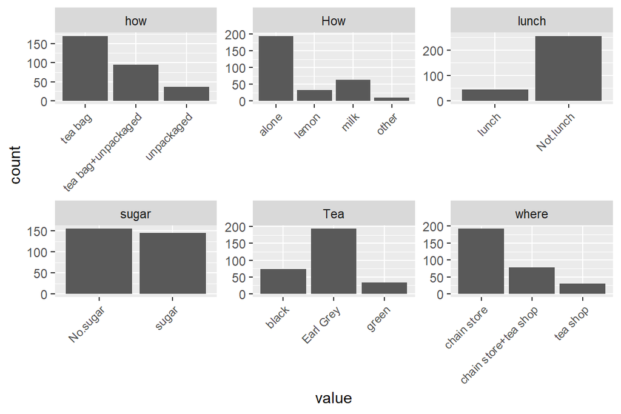

```r
gather(tea_time) %>% ggplot(aes(value)) + facet_wrap("key", scales = "free") + geom_bar() + theme(axis.text.x = element_text(angle = 45, hjust = 1, size = 8))
```

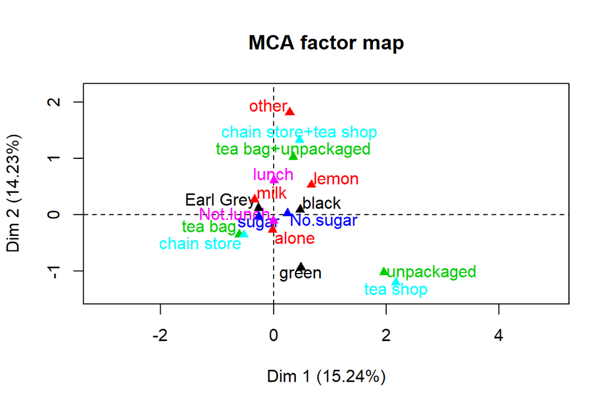

```r
mac <- MCA(tea_time, graph = FALSE)
plot(mac, invisible=c("ind"), habillage = "quali")
```

# Chapter 6: Longtitudinal data

this week exercises is based on the Chapters 8 and 9 of Vehkalahti and Everitt (2019), included in the special edition MABS4IODS (Part VI) we work with two dataset, BPRS and RATS, and perform the analyses based on swapping method.

## first dataset RATS

This dataset RATS has 16 rats for study, and they are divided into 3 groups based on different diets.

```r
library(ggplot2)
library(tidyr)
library(dplyr)
RATSL <- read.csv(file = "C:/Users/ferozef/Documents/R/IODS-project/data/RATSL.csv", row.names = 1)

# categorials into factors
RATSL$Group <- factor(RATSL$Group)
RATSL$ID <- factor(RATSL$ID)
# stardardize bprsl
RATSL <- RATSL %>% group_by(Time) %>% mutate(stweight = (Weight - mean(Weight)) / sd(Weight)) %>% ungroup()
str(RATSL)
```

```
## Classes 'tbl_df', 'tbl' and 'data.frame':    176 obs. of  6 variables:
##  $ ID      : Factor w/ 16 levels "1","2","3","4",..: 1 2 3 4 5 6 7 8 9 10 ...
##  $ Group   : Factor w/ 3 levels "1","2","3": 1 1 1 1 1 1 1 1 2 2 ...
##  $ WD      : Factor w/ 11 levels "WD1","WD15","WD22",..: 1 1 1 1 1 1 1 1 1 1 ...
##  $ Weight  : int  240 225 245 260 255 260 275 245 410 405 ...
##  $ Time    : int  1 1 1 1 1 1 1 1 1 1 ...
##  $ stweight: num  -1.001 -1.12 -0.961 -0.842 -0.882 ...
```

## Graphical exploration of longtitudinal data

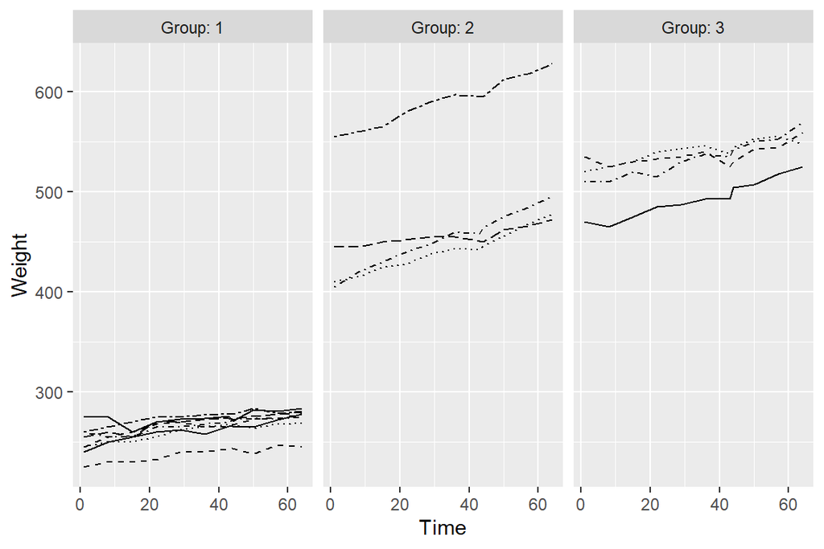

```r
# plot the individuals in time with standardized bprs value
ggplot(RATSL, aes(x = Time, y = Weight, linetype = ID)) + geom_line() + facet_grid(. ~ Group, labeller = label_both) + scale_linetype_manual(values = rep(1:6, times=4)) + theme(legend.position = "none") +   scale_y_continuous(limits = c(min(RATSL$Weight), max(RATSL$Weight)))
```

The diet has influenced the rats wieght and all the rats has shown to gain weight. Comparing all the 3 group, Group1 rats are at the baseline whereas, Group 2 and 3 has higher weight and variability compared to Group1

```r
# Summary plot
# Number of timepoints, baseline included
n <- RATSL$Time %>% unique() %>% length()
# Summarize mean and std error
rats_sum <- RATSL %>% group_by(Group, Time) %>% summarise(mean = mean(Weight), se = ( sd(Weight) / sqrt(n) )) %>% ungroup()
glimpse(rats_sum)
```

```
## Observations: 33
## Variables: 4
## $ Group <fct> 1, 1, 1, 1, 1, 1, 1, 1, 1, 1, 1, 2, 2, 2, 2, 2, 2, 2, 2,...
## $ Time  <int> 1, 8, 15, 22, 29, 36, 43, 44, 50, 57, 64, 1, 8, 15, 22, ...
## $ mean  <dbl> 250.625, 255.000, 254.375, 261.875, 264.625, 265.000, 26...
## $ se    <dbl> 4.589478, 3.947710, 3.460116, 4.100800, 3.333956, 3.5529...
```

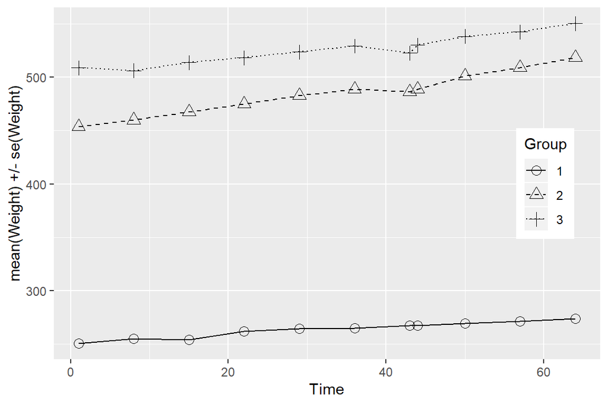

```r
# plot the plots
par(mfrow = c(1,2))
# with means only
ggplot(rats_sum, aes(x = Time, y = mean, linetype = Group, shape = Group)) +
  geom_line() +
  scale_linetype_manual(values = c(1,2,3)) +
  geom_point(size=3) +
  scale_shape_manual(values = c(1,2,3)) +
  theme(legend.position = c(0.9,0.5)) +
  scale_y_continuous(name = "mean(Weight) +/- se(Weight)")
```

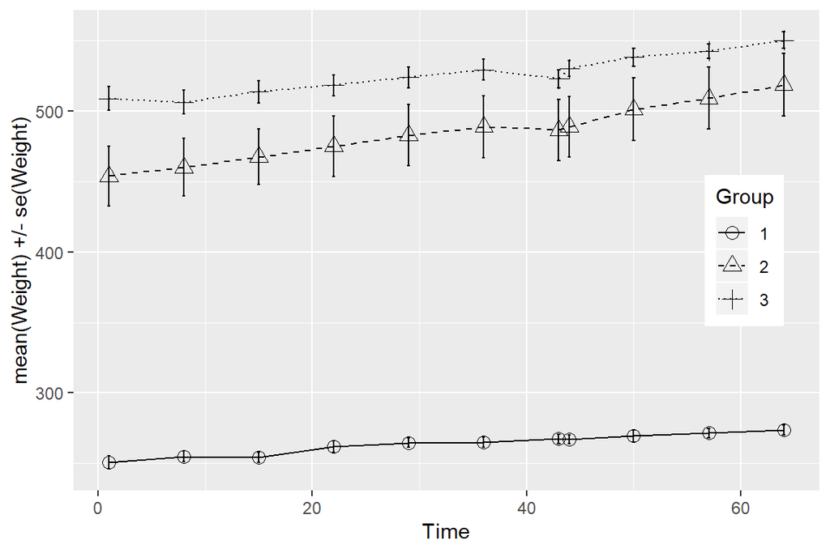

```r
# added with the error bar
ggplot(rats_sum, aes(x = Time, y = mean, linetype = Group, shape = Group)) +
  geom_line() +
  scale_linetype_manual(values = c(1,2,3)) +
  geom_point(size=3) +
  scale_shape_manual(values = c(1,2,3)) +
  geom_errorbar(aes(ymin=mean-se, ymax=mean+se, linetype="1"), width=0.3) +
  theme(legend.position = c(0.9,0.5)) +
  scale_y_continuous(name = "mean(Weight) +/- se(Weight)")
```

from the above graph, we can conclude that all the 3 groups weight increase by time.

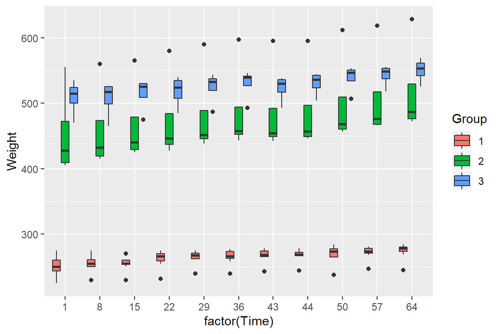

```r
# boxplot
ggplot(RATSL, aes(x = factor(Time), y = Weight, fill = Group)) + geom_boxplot()
```

Boxplots with non-summarized data.

## Preparinf the summary measure approach

```r
# Summary measure approach, filter out outliers
# create the summary dataset with means from the weeks 1-8
rat8s <- RATSL %>%
  filter(Time > 0) %>%
  group_by(Group, ID) %>%
  summarise( mean=mean(Weight) ) %>%
  ungroup()
glimpse(rat8s)
```

```
## Observations: 16
## Variables: 3
## $ Group <fct> 1, 1, 1, 1, 1, 1, 1, 1, 2, 2, 2, 2, 3, 3, 3, 3
## $ ID    <fct> 1, 2, 3, 4, 5, 6, 7, 8, 9, 10, 11, 12, 13, 14, 15, 16
## $ mean  <dbl> 261.0909, 237.6364, 260.1818, 266.5455, 269.4545, 274.72...
```

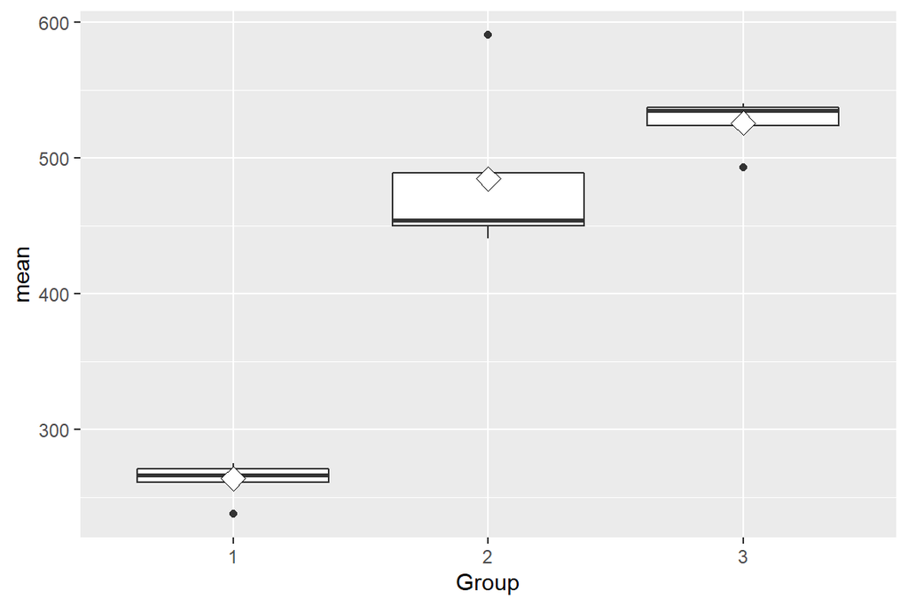

```r
ggplot(rat8s, aes(x=Group, y = mean)) + geom_boxplot() + stat_summary(fun.y = "mean", geom = "point", shape=23, size=4, fill = "white")
```

From the above boxplot, we can clearly see the outliers present in the group, let’s filter out the outliers from the data.

```r
# filtering out the outlier's and re-plotting the box plot again

rat8s1 <- filter(rat8s, Group == 2 & mean < 550 | Group == 1 & mean > 260 | Group == 3 & mean > 500)
glimpse(rat8s1)
```

```
## Observations: 13
## Variables: 3
## $ Group <fct> 1, 1, 1, 1, 1, 1, 1, 2, 2, 2, 3, 3, 3
## $ ID    <fct> 1, 3, 4, 5, 6, 7, 8, 9, 10, 11, 14, 15, 16
## $ mean  <dbl> 261.0909, 260.1818, 266.5455, 269.4545, 274.7273, 274.63...
```

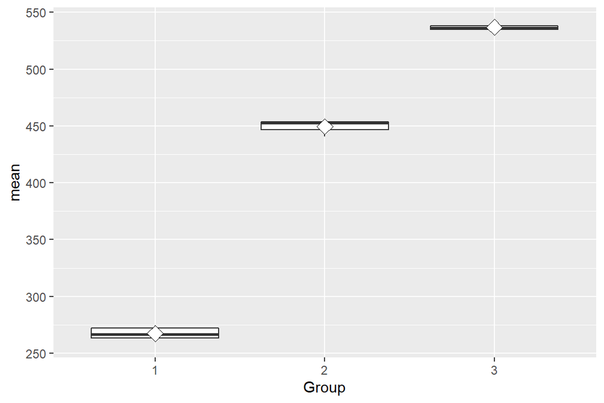

```r
ggplot(rat8s1, aes(x=Group, y = mean)) + geom_boxplot() + stat_summary(fun.y = "mean", geom = "point", shape=23, size=4, fill = "white")
```

From the above box plot 2, we can see that the outlier’s has been filtered out and the data now seems to be good.

## Summary approach, comparing means

```r
summary(aov(mean ~ Group, data = rat8s1))
```

```
##             Df Sum Sq Mean Sq F value   Pr(>F)
## Group        2 175958   87979    2577 2.72e-14 ***
## Residuals   10    341      34
## ---
## Signif. codes:  0 '***' 0.001 '**' 0.01 '*' 0.05 '.' 0.1 ' ' 1
```

```r
kruskal.test(mean ~ Group, data = rat8s1)
```

```
##
##  Kruskal-Wallis rank sum test
##
## data:  mean by Group
## Kruskal-Wallis chi-squared = 9.8901, df = 2, p-value = 0.007119
```

```r
# covariance analysis with the baseline
# add the baseline from the original wide dataset to the summary data
rats <- read.csv(file = "C:/Users/ferozef/Documents/R/IODS-project/data/RATS.csv", row.names = 1)
rat8s2 <- rat8s %>% mutate(baseline = rats$WD1)
glimpse(rat8s2)
```

```
## Observations: 16
## Variables: 4
## $ Group    <fct> 1, 1, 1, 1, 1, 1, 1, 1, 2, 2, 2, 2, 3, 3, 3, 3
## $ ID       <fct> 1, 2, 3, 4, 5, 6, 7, 8, 9, 10, 11, 12, 13, 14, 15, 16
## $ mean     <dbl> 261.0909, 237.6364, 260.1818, 266.5455, 269.4545, 274...
## $ baseline <int> 240, 225, 245, 260, 255, 260, 275, 245, 410, 405, 445...
```

```r
# Fittinf linear regression model
fit <- lm(mean ~ baseline + Group, data = rat8s2)
summary(fit)
```

```
##
## Call:
## lm(formula = mean ~ baseline + Group, data = rat8s2)
##
## Residuals:
##     Min      1Q  Median      3Q     Max
## -21.732  -3.812   1.991   6.889  13.455
##
## Coefficients:
##             Estimate Std. Error t value Pr(>|t|)
## (Intercept) 30.14886   19.88779   1.516   0.1554
## baseline     0.93194    0.07793  11.959 5.02e-08 ***
## Group2      31.68866   17.11189   1.852   0.0888 .
## Group3      21.52296   21.13931   1.018   0.3287
## ---
## Signif. codes:  0 '***' 0.001 '**' 0.01 '*' 0.05 '.' 0.1 ' ' 1
##
## Residual standard error: 10.62 on 12 degrees of freedom
## Multiple R-squared:  0.9947, Adjusted R-squared:  0.9933
## F-statistic: 747.8 on 3 and 12 DF,  p-value: 6.636e-14
```

The covariance analysis reveals, that the baseline is highly related to the means with 5.02e-08 ***. And, after controlling the baseline, there is no significant diffence left between the group means.

## BPRS

Do the growth profiles of the treatment groups differ?

```r
# read the data, in long form
bprsl <- read.csv(file = "C:/Users/ferozef/Documents/R/IODS-project/data/BPRSL.csv", row.names = 1)
bprsl$treatment <- factor(bprsl$treatment)
bprsl$subject <- factor(bprsl$subject)
glimpse(bprsl)
```

```
## Observations: 360
## Variables: 4
## $ treatment <fct> 1, 1, 1, 1, 1, 1, 1, 1, 1, 1, 1, 1, 1, 1, 1, 1, 1, 1...
## $ subject   <fct> 1, 2, 3, 4, 5, 6, 7, 8, 9, 10, 11, 12, 13, 14, 15, 1...
## $ weeks     <int> 0, 0, 0, 0, 0, 0, 0, 0, 0, 0, 0, 0, 0, 0, 0, 0, 0, 0...
## $ bprs      <int> 42, 58, 54, 55, 72, 48, 71, 30, 41, 57, 30, 55, 36, ...
```

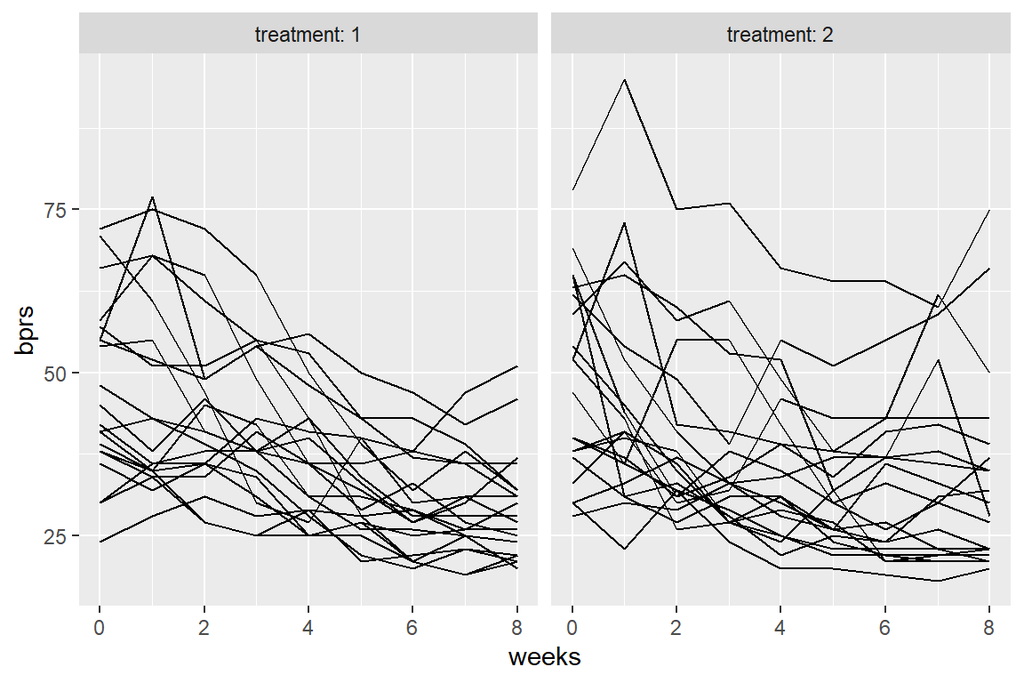

```r
ggplot(bprsl, aes(x = weeks, y = bprs, group = subject)) + geom_line() + facet_grid(. ~ treatment, labeller = label_both)
```

```r
bps_reg <- lm(bprs ~ weeks + treatment, data=bprsl)
summary(bps_reg)
```

```
##
## Call:
## lm(formula = bprs ~ weeks + treatment, data = bprsl)
##
## Residuals:
##     Min      1Q  Median      3Q     Max
## -22.454  -8.965  -3.196   7.002  50.244
##
## Coefficients:
##             Estimate Std. Error t value Pr(>|t|)
## (Intercept)  46.4539     1.3670  33.982   <2e-16 ***
## weeks        -2.2704     0.2524  -8.995   <2e-16 ***
## treatment2    0.5722     1.3034   0.439    0.661
## ---
## Signif. codes:  0 '***' 0.001 '**' 0.01 '*' 0.05 '.' 0.1 ' ' 1
##
## Residual standard error: 12.37 on 357 degrees of freedom
## Multiple R-squared:  0.1851, Adjusted R-squared:  0.1806
## F-statistic: 40.55 on 2 and 357 DF,  p-value: < 2.2e-16
```

### Random intercept model

```r
library(lme4)
bps_ref <- lmer(bprs ~ weeks + treatment + (1|subject), data = bprsl, REML=FALSE)
summary(bps_ref)
```

```
## Linear mixed model fit by maximum likelihood  ['lmerMod']
## Formula: bprs ~ weeks + treatment + (1 | subject)
##    Data: bprsl
##
##      AIC      BIC   logLik deviance df.resid
##   2748.7   2768.1  -1369.4   2738.7      355
##
## Scaled residuals:
##     Min      1Q  Median      3Q     Max
## -3.0481 -0.6749 -0.1361  0.4813  3.4855
##
## Random effects:
##  Groups   Name        Variance Std.Dev.
##  subject  (Intercept)  47.41    6.885
##  Residual             104.21   10.208
## Number of obs: 360, groups:  subject, 20
##
## Fixed effects:
##             Estimate Std. Error t value
## (Intercept)  46.4539     1.9090  24.334
## weeks        -2.2704     0.2084 -10.896
## treatment2    0.5722     1.0761   0.532
##
## Correlation of Fixed Effects:
##            (Intr) weeks
## weeks      -0.437
## treatment2 -0.282  0.000
```

### Random intercept and random slope model

```r
bps_ref2 <- lmer(bprs ~ weeks + treatment + (weeks|subject), data = bprsl, REML=FALSE)
summary(bps_ref2)
```

```
## Linear mixed model fit by maximum likelihood  ['lmerMod']
## Formula: bprs ~ weeks + treatment + (weeks | subject)
##    Data: bprsl
##
##      AIC      BIC   logLik deviance df.resid
##   2745.4   2772.6  -1365.7   2731.4      353
##
## Scaled residuals:
##     Min      1Q  Median      3Q     Max
## -2.8919 -0.6194 -0.0691  0.5531  3.7977
##
## Random effects:
##  Groups   Name        Variance Std.Dev. Corr
##  subject  (Intercept) 64.8222  8.0512
##           weeks        0.9609  0.9803   -0.51
##  Residual             97.4304  9.8707
## Number of obs: 360, groups:  subject, 20
##
## Fixed effects:
##             Estimate Std. Error t value
## (Intercept)  46.4539     2.1052  22.066
## weeks        -2.2704     0.2977  -7.626
## treatment2    0.5722     1.0405   0.550
##
## Correlation of Fixed Effects:
##            (Intr) weeks
## weeks      -0.582
## treatment2 -0.247  0.000
```

```r
anova(bps_ref, bps_ref2)
```

```
## Data: bprsl
## Models:
## bps_ref: bprs ~ weeks + treatment + (1 | subject)
## bps_ref2: bprs ~ weeks + treatment + (weeks | subject)
##          Df    AIC    BIC  logLik deviance  Chisq Chi Df Pr(>Chisq)
## bps_ref   5 2748.7 2768.1 -1369.4   2738.7
## bps_ref2  7 2745.4 2772.6 -1365.7   2731.4 7.2721      2    0.02636 *
## ---
## Signif. codes:  0 '***' 0.001 '**' 0.01 '*' 0.05 '.' 0.1 ' ' 1
```

The model fit is better in model 2.

### Random intercept and random slope model with interaction

```r
bps_ref3 <- lmer(bprs ~ weeks * treatment + (weeks|subject), data = bprsl, REML=FALSE)
summary(bps_ref3)
```

```
## Linear mixed model fit by maximum likelihood  ['lmerMod']
## Formula: bprs ~ weeks * treatment + (weeks | subject)
##    Data: bprsl
##
##      AIC      BIC   logLik deviance df.resid
##   2744.3   2775.4  -1364.1   2728.3      352
##
## Scaled residuals:
##     Min      1Q  Median      3Q     Max
## -3.0512 -0.6271 -0.0768  0.5288  3.9260
##
## Random effects:
##  Groups   Name        Variance Std.Dev. Corr
##  subject  (Intercept) 64.9964  8.0620
##           weeks        0.9687  0.9842   -0.51
##  Residual             96.4707  9.8220
## Number of obs: 360, groups:  subject, 20
##
## Fixed effects:
##                  Estimate Std. Error t value
## (Intercept)       47.8856     2.2521  21.262
## weeks             -2.6283     0.3589  -7.323
## treatment2        -2.2911     1.9090  -1.200
## weeks:treatment2   0.7158     0.4010   1.785
##
## Correlation of Fixed Effects:
##             (Intr) weeks  trtmn2
## weeks       -0.650
## treatment2  -0.424  0.469
## wks:trtmnt2  0.356 -0.559 -0.840
```

```r
anova(bps_ref2, bps_ref3)
```

```
## Data: bprsl
## Models:
## bps_ref2: bprs ~ weeks + treatment + (weeks | subject)
## bps_ref3: bprs ~ weeks * treatment + (weeks | subject)
##          Df    AIC    BIC  logLik deviance  Chisq Chi Df Pr(>Chisq)
## bps_ref2  7 2745.4 2772.6 -1365.7   2731.4
## bps_ref3  8 2744.3 2775.4 -1364.1   2728.3 3.1712      1    0.07495 .
## ---
## Signif. codes:  0 '***' 0.001 '**' 0.01 '*' 0.05 '.' 0.1 ' ' 1
```

The fit is not significantly better in model 3.

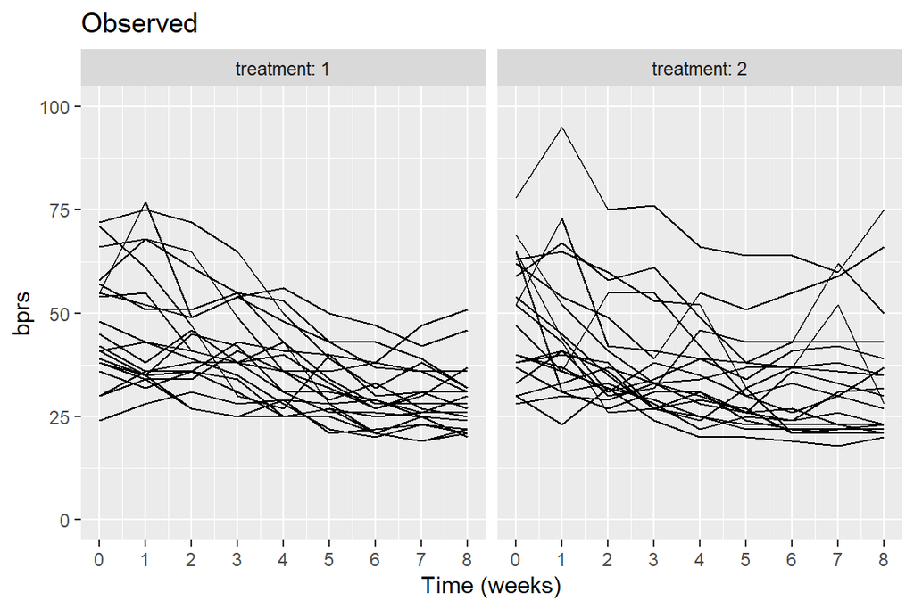

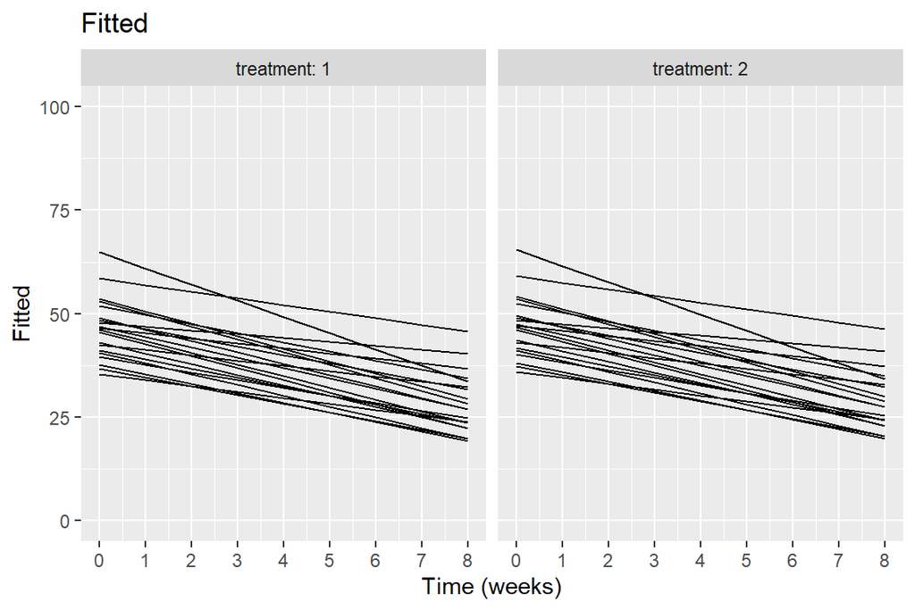

```r
# Create a vector of the fitted values
Fitted <- fitted(bps_ref2)
bprsl <- bprsl %>% mutate(Fitted)
# draw the plot of BPRSL with the observed bprs values
p1 <- ggplot(bprsl, aes(x = weeks, y = bprs, group = subject)) + geom_line() + facet_grid(. ~ treatment, labeller = label_both) + scale_x_continuous(name = "Time (weeks)", breaks = seq(0, 8, 1)) +  ylim(0,100) + theme(legend.position = "top") + ggtitle("Observed")
# draw the plot with fitted
p2 <- ggplot(bprsl, aes(x = weeks, y = Fitted, group = subject)) +
  geom_line() + facet_grid(. ~ treatment, labeller = label_both) +
  scale_x_continuous(name = "Time (weeks)", breaks = seq(0, 8, 1)) +
  ylim(0, 100) +
  theme(legend.position = "top") + ggtitle("Fitted")
p1; p2
```